# QTM 151 - Quiz 1

## Try to submit as an HTML file

Print your name below

```python
# Write your own code

print("Ben Zamler")
```

```
Ben Zamler
```

This quiz is open book

- You can use the lecture notes
- You will get partial credit for attempting the questions
- To get full credit, the code should run as intended
- You should NOT communicate with other students

Print the following message:

"I will abide by Emory's code of conduct"

```python
# Write your own code


print("I will abide by Emory's code of conduct")
```

```
I will abide by Emory's code of conduct
```

Import the libraries "numpy", "matplotlib.pytplot", and "pandas"

```python
# Write your own code

import numpy as np
import matplotlib.pyplot as plt
import pandas as pd
```

## Part I: Visualizing random variables

(a) Create two random variables ...

- Call them "vec_x" and "vec_z"
- Generate "vec_x" from a uniform distribution with (low = 10, high = 20, size = 1000)
- Generate "vec_z" from a uniform distribution with (low = -2, high = 5, size = 1000)
- Plot a histogram of each variable
  - Label the axes and title
  - Each graph should have a different title

To get full points, plot the histograms on a grid (See Lecture 6)

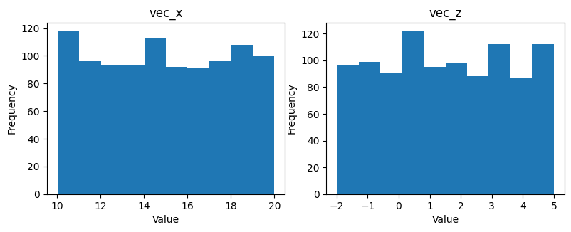

```python
# Write your own code

vec_x = np.random.uniform(low=10,high=20,size=1000)
vec_z = np.random.uniform(low=-2,high=5,size=1000)

fig,list_subfig = plt.subplots(1,2,figsize=(8,3))
plt.tight_layout()

list_subfig[0].hist(x = vec_x)
list_subfig[0].set_title("vec_x")
list_subfig[0].set_xlabel("Value")
list_subfig[0].set_ylabel("Frequency")


list_subfig[1].hist(x = vec_z)
list_subfig[1].set_title("vec_z")
list_subfig[1].set_xlabel("Value")
list_subfig[1].set_ylabel("Frequency")
```

(b) Create a new variable "vec_y" by the formula

$ y = e^x + 2x + 5$

- Use element-by-element vector operations (no loops)
- Produce a scatter plot of "vec_y" against "vec_x"
- Label the axes and the title
- Change the color to "red", "green" or "purple" (you choose)

Hint: You can use the numpy "exp()" function with vector arrays

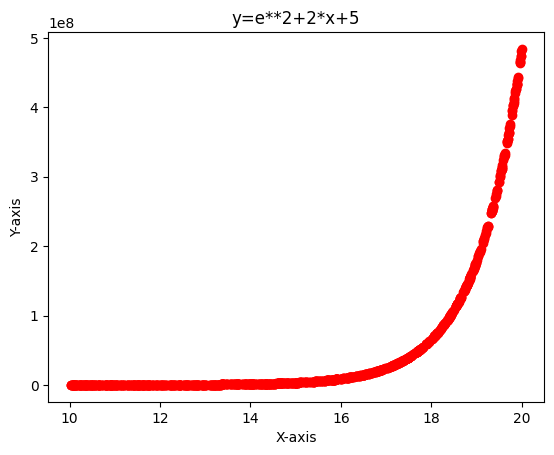

```python
# Write your own code

vec_y =np.e**vec_x+2*vec_x+5

plt.scatter(x = vec_x, y = vec_y,color="red")
plt.title("y=e**2+2*x+5")
plt.xlabel("X-axis")
plt.ylabel("Y-axis")
```

## Part II: Operations over multiple datasets

(c) Create two lists with ...

- The names of the datasets
- The years of the datasets (type manually based on the dataset names)

To answer this question, you need to browse the Quiz folder

You will find three datasets on the distribution of ages worldwide

```python
# Write your own code

wdi_data1 = pd.read_csv("data_quiz/wdi_agedist_1980.csv")
wdi_data2 = pd.read_csv("data_quiz/wdi_agedist_2000.csv")
wdi_data3 = pd.read_csv("data_quiz/wdi_agedist_2020.csv")

list_wdi = [wdi_data1,wdi_data2,wdi_data3]
list_years = [1980,2020,2000]

print(list_wdi)
```

```
[       year yearcode     countryname countrycode  percent_ages0to14  \
0    1980.0   YR1980     Afghanistan         AFG          45.972855
1    1980.0   YR1980         Albania         ALB          36.306595
2    1980.0   YR1980         Algeria         DZA          46.408476
3    1980.0   YR1980  American Samoa         ASM          41.576075
4    1980.0   YR1980         Andorra         AND          23.732835
..      ...      ...             ...         ...                ...
265  1980.0   YR1980           World         WLD          35.387187
266     NaN      NaN             NaN         NaN                NaN
267     NaN      NaN             NaN         NaN                NaN
268     NaN      NaN             NaN         NaN                NaN
269     NaN      NaN             NaN         NaN                NaN

     percent_ages15to64
0             51.502597
```

[output cut: 64 more lines]

(d) Create a loop that ...

- Goes over the list of years
- If the year $\ge$ 2008, print the message

$\qquad$ "This dataset contains information on or after 2008.

- If the year $<$ 2008, print the message

$\qquad$ "This dataset contains information before 2008"

```python
# Write your own code


list_years = [2020,2000]

for year in list_years:
    if year >=2008:
        print("This dataset contains information on or after 2008")
    else:
        print("This dataset contains information before 2008")
```

```
This dataset contains information on or after 2008
This dataset contains information before 2008
```

(e) Your goal is to convert all the ".csv" data files to ".xlsx" (Excel) files

- Create a list with the ".csv" dataset names (including their relative subfolder "data_quiz/)
- Create a new list called "list_newnames", with each element ending in ".xlsx" (including the subfolder "data_excel/")
- Start an index

$\qquad$ index = 0

- Initiate a for loop over the list of dataset names. Inside the loop:
  - Read the ".csv" dataset and store it in an object called "dataset"
  - Create a variable called "filename" from the "list_newnames", extracting the element "index"
  - Store "dataset" as an excel file with name "filename".

  $\qquad$ index = index + 1

Note: Check that you did it correctly by trying to open your new excel files outside "VSCode"

```python
# Write your own code

csv_list = ["data_quiz/wdi_agedist_1980.csv", "data_quiz/wdi_agedist_2000.csv", "data_quiz/wdi_agedist_2020.csv"]

index=0
for file in csv_list:
    dataset = pd.read_csv(csv_list[index])
    filename = csv_list[index].to_excel("data_quiz" + str([index + 1]) +".xlsx")
    index=index+1
```

[output not shown]

(f) Your goal is to open each dataset, create a new variable, then plot

- Create a list with the ".csv" dataset names (including their relative subfolder "data_quiz/)
- Start an index

$\qquad$ index = 0

- Initiate a for loop over the list of dataset names. Inside the loop:
  - Read the dataset and store it in an object called "dataset"
  - Create two new variables as

  $\qquad$ percent_ages0to14 = dataset["percent_ages0to14"]
  - Calculate the proportion of the population 15 or older by computing "100 - percent_ages0to14".
  - Plot a histogram and label the axes
  - Use plt.show() to display the plot
  - Write

  $\qquad$ index = index + 1

This should produce a histogram for each dataset

```python
# Write your own code

csv_list = ["data_quiz/wdi_agedist_1980.csv", "data_quiz/wdi_agedist_2000.csv", "data_quiz/wdi_agedist_2020.csv"]

index=0
for something in csv_list:
    dataset = pd.read.csv
    percent_ages0to14 = dataset["percent_ages0to14"]
```

[output not shown]